# Chapter 04: Time series features

maurogm 2022-12-13

- Link
- Some simple statistics
- ACF features
- STL features
- Otros features
- Ejemplo de exploración

Más que nada se explorarán las capacidades del paquete `feasts` (FEatures And Statistics from Time Series).

## Link

https://otexts.com/fpp3/features.html

## Some simple statistics

```r
tourism %>% features(Trips, quantile)
```

```
## # A tibble: 304 × 8
##    Region         State              Purpose     `0%`  `25%`   `50%`  `75%` `100%`
##    <chr>          <chr>              <chr>      <dbl>  <dbl>   <dbl>  <dbl>  <dbl>
##  1 Adelaide       South Australia    Business  68.7   134.   153.    177.   242.
##  2 Adelaide       South Australia    Holiday  108.    135.   154.    172.   224.
##  3 Adelaide       South Australia    Other     25.9    43.9   53.8    62.5  107.
##  4 Adelaide       South Australia    Visiting 137.    179.   206.    229.   270.
##  5 Adelaide Hills South Australia    Business   0       0      1.26    3.92  28.6
##  6 Adelaide Hills South Australia    Holiday    0       5.77   8.52   14.1   35.8
##  7 Adelaide Hills South Australia    Other      0       0      0.908   2.09   8.95
##  8 Adelaide Hills South Australia    Visiting   0.778   8.91  12.2    16.8   81.1
##  9 Alice Springs  Northern Territory Business   1.01    9.13  13.3    18.5   34.1
## 10 Alice Springs  Northern Territory Holiday    2.81   16.9   31.5    44.8   76.5
## # … with 294 more rows
```

## ACF features

La función `feat_acf` devuelve la siguiente información:

- the first autocorrelation coefficient from the original data;
- the sum of squares of the first ten autocorrelation coefficients from the original data;
- the first autocorrelation coefficient from the differenced data;
- the sum of squares of the first ten autocorrelation coefficients from the differenced data;
- the first autocorrelation coefficient from the twice differenced data;
- the sum of squares of the first ten autocorrelation coefficients from the twice differenced data;
- For seasonal data, the autocorrelation coefficient at the first seasonal lag is also returned.

```r
tourism %>% features(Trips, feat_acf)
```

```
## # A tibble: 304 × 10
##    Region         State              Purpose      acf1 acf10 diff1_acf1 diff1_acf10 diff2_acf1 diff2_acf10 season_acf1
##    <chr>          <chr>              <chr>       <dbl> <dbl>      <dbl>       <dbl>      <dbl>       <dbl>       <dbl>
##  1 Adelaide       South Australia    Business  0.0333  0.131     -0.520       0.463     -0.676       0.741      0.201
##  2 Adelaide       South Australia    Holiday   0.0456  0.372     -0.343       0.614     -0.487       0.558      0.351
##  3 Adelaide       South Australia    Other     0.517   1.15      -0.409       0.383     -0.675       0.792      0.342
##  4 Adelaide       South Australia    Visiting  0.0684  0.294     -0.394       0.452     -0.518       0.447      0.345
##  5 Adelaide Hills South Australia    Business  0.0709  0.134     -0.580       0.415     -0.750       0.746     -0.0628
##  6 Adelaide Hills South Australia    Holiday   0.131   0.313     -0.536       0.500     -0.716       0.906      0.208
##  7 Adelaide Hills South Australia    Other     0.261   0.330     -0.253       0.317     -0.457       0.392      0.0745
##  8 Adelaide Hills South Australia    Visiting  0.139   0.117     -0.472       0.239     -0.626       0.408      0.170
##  9 Alice Springs  Northern Territory Business  0.217   0.367     -0.500       0.381     -0.658       0.587      0.315
## 10 Alice Springs  Northern Territory Holiday  -0.00660 2.11      -0.153       2.11      -0.274       1.55       0.729
## # … with 294 more rows
```

## STL features

La función `feat_stl` devuelve la siguiente información:

- trend_strength mide la fuerza del trend component de la descomposición STL. Se mide en función de la diferencia entre la varianza desestacionalizada y la varianza del componente Residual. Si la diferencia es mucha, es porque el componente Trend explica mucha más varianza que el componente de los residuos.
- seasonal_strength es análogo, pero midiendo la fuerza del componente estacional, y se calcula comparando la varianza *destrendizada* con la de los residuos.
- seasonal_peak_year indicates the timing of the peaks — which month or quarter contains the largest seasonal component. This tells us something about the nature of the seasonality. In the Australian tourism data, if Quarter 3 is the peak seasonal period, then people are travelling to the region in winter, whereas a peak in Quarter 1 suggests that the region is more popular in summer.
- seasonal_trough_year indicates the timing of the troughs — which month or quarter contains the smallest seasonal component.
- spikiness measures the prevalence of spikes in the remainder component Rt of the STL decomposition. It is the variance of the leave-one-out variances of Rt.
- linearity measures the linearity of the trend component of the STL decomposition. It is based on the coefficient of a linear regression applied to the trend component.
- curvature measures the curvature of the trend component of the STL decomposition. It is based on the coefficient from an orthogonal quadratic regression applied to the trend component.
- stl_e_acf1 is the first autocorrelation coefficient of the remainder series.
- stl_e_acf10 is the sum of squares of the first ten autocorrelation coefficients of the remainder series.

```r
tourism %>% features(Trips, feat_stl)
```

```
## # A tibble: 304 × 12
##    Region         State              Purpose  trend_strength seasonal_strength_year seasonal_peak_year seasonal_trough_year  spikiness linearity curvature stl_e_acf1 stl_e_acf10
##    <chr>          <chr>              <chr>             <dbl>                  <dbl>              <dbl>                <dbl>      <dbl>     <dbl>     <dbl>      <dbl>       <dbl>
##  1 Adelaide       South Australia    Business          0.464                  0.407                  3                    1 158.          -5.31     71.6       -0.532       0.594
##  2 Adelaide       South Australia    Holiday           0.554                  0.619                  1                    2   9.17        49.0      78.7       -0.510       0.561
##  3 Adelaide       South Australia    Other             0.746                  0.202                  2                    1   2.10        95.1      43.4       -0.351       0.403
##  4 Adelaide       South Australia    Visiting          0.435                  0.452                  1                    3  56.1         34.6      71.4       -0.501       1.01
##  5 Adelaide Hills South Australia    Business          0.464                  0.179                  3                    0   0.103        0.968    -3.22      -0.600       0.497
##  6 Adelaide Hills South Australia    Holiday           0.528                  0.296                  2                    1   0.177       10.5      24.0       -0.481       0.350
##  7 Adelaide Hills South Australia    Other             0.593                  0.404                  2                    2   0.000444     4.28      3.19      -0.298       0.281
##  8 Adelaide Hills South Australia    Visiting          0.488                  0.254                  0                    3   6.50        34.2      -0.529     -0.472       0.446
##  9 Alice Springs  Northern Territory Business          0.534                  0.251                  0                    1   0.169       23.8      19.5       -0.492       0.548
## 10 Alice Springs  Northern Territory Holiday           0.381                  0.832                  3                    1   0.739      -19.6      10.5       -0.522       0.726
## # … with 294 more rows
```

Esto es útil si se tienen muchas series diferentes y se quiere comparar sus características. Por ejemplo haciendo lo siguiente se ve que los viajes vacacionales son los más afectados por la estacionalidad:

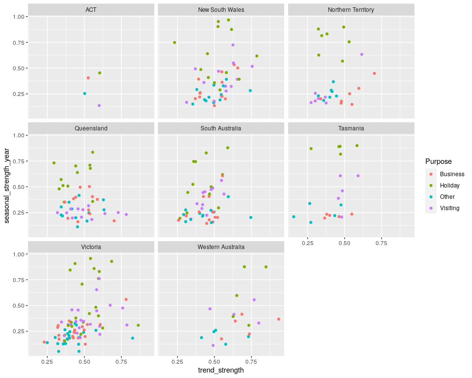

```r
tourism %>%
  features(Trips, feat_stl) %>%
  ggplot(aes(x = trend_strength, y = seasonal_strength_year,
             col = Purpose)) +
  geom_point() +
  facet_wrap(vars(State))
```

## Otros features

A continuación se listan muchos más features, muchos de los cuales se discuten en otros lados del libro:

- coef_hurst will calculate the Hurst coefficient of a time series which is a measure of “long memory”. A series with long memory will have significant autocorrelations for many lags.
- feat_spectral will compute the (Shannon) spectral entropy of a time series, which is a measure of how easy the series is to forecast. A series which has strong trend and seasonality (and so is easy to forecast) will have entropy close to 0. A series that is very noisy (and so is difficult to forecast) will have entropy close to 1.
- box_pierce gives the Box-Pierce statistic for testing if a time series is white noise, and the corresponding p-value. This test is discussed in Section 5.4.
- ljung_box gives the Ljung-Box statistic for testing if a time series is white noise, and the corresponding p-value. This test is discussed in Section 5.4.
- The kth partial autocorrelation measures the relationship between observations k periods apart after removing the effects of observations between them. So the first partial autocorrelation (k=1) is identical to the first autocorrelation, because there is nothing between consecutive observations to remove. Partial autocorrelations are discussed in Section 9.5. The feat_pacf function contains several features involving partial autocorrelations including the sum of squares of the first five partial autocorrelations for the original series, the first-differenced series and the second-differenced series. For seasonal data, it also includes the partial autocorrelation at the first seasonal lag.
- unitroot_kpss gives the Kwiatkowski-Phillips-Schmidt-Shin (KPSS) statistic for testing if a series is stationary, and the corresponding p-value. This test is discussed in Section 9.1.
- unitroot_pp gives the Phillips-Perron statistic for testing if a series is non-stationary, and the corresponding p-value.
- unitroot_ndiffs gives the number of differences required to lead to a stationary series based on the KPSS test. This is discussed in Section 9.1
- unitroot_nsdiffs gives the number of seasonal differences required to make a series stationary. This is discussed in Section 9.1.
- var_tiled_mean gives the variances of the “tiled means” (i.e., the means of consecutive non-overlapping blocks of observations). The default tile length is either 10 (for non-seasonal data) or the length of the seasonal period. This is sometimes called the “stability” feature.
- var_tiled_var gives the variances of the “tiled variances” (i.e., the variances of consecutive non-overlapping blocks of observations). This is sometimes called the “lumpiness” feature.
- shift_level_max finds the largest mean shift between two consecutive sliding windows of the time series. This is useful for finding sudden jumps or drops in a time series.
- shift_level_index gives the index at which the largest mean shift occurs.
- shift_var_max finds the largest variance shift between two consecutive sliding windows of the time series. This is useful for finding sudden changes in the volatility of a time series.
- shift_var_index gives the index at which the largest variance shift occurs.
- shift_kl_max finds the largest distributional shift (based on the Kulback-Leibler divergence) between two consecutive sliding windows of the time series. This is useful for finding sudden changes in the distribution of a time series.
- shift_kl_index gives the index at which the largest KL shift occurs.
- n_crossing_points computes the number of times a time series crosses the median.
- longest_flat_spot computes the number of sections of the data where the series is relatively unchanging.
- stat_arch_lm returns the statistic based on the Lagrange Multiplier (LM) test of Engle (1982) for autoregressive conditional heteroscedasticity (ARCH).
- guerrero computes the optimal λ value for a Box-Cox transformation using the Guerrero method (discussed in Section 3.1).

## Ejemplo de exploración

El paquete `feasts` tiene muchas más features. Es posible calcularlas todas de este modo:

```r
tourism_features <- tourism %>%
  features(Trips, feature_set(pkgs = "feasts"))
tourism_features
```

```
## # A tibble: 304 × 50
##    Region       State Purpose trend_strength seasonal_streng… seasonal_peak_y… seasonal_trough… spikiness linearity curvature stl_e_acf1 stl_e_acf10     acf1 acf10 diff1_acf1 diff1_acf10
##    <chr>        <chr> <chr>            <dbl>            <dbl>            <dbl>            <dbl>     <dbl>     <dbl>     <dbl>      <dbl>       <dbl>    <dbl> <dbl>      <dbl>       <dbl>
##  1 Adelaide     Sout… Busine…          0.464            0.407                3                1   1.58e+2    -5.31     71.6       -0.532       0.594  0.0333  0.131     -0.520       0.463
##  2 Adelaide     Sout… Holiday          0.554            0.619                1                2   9.17e+0    49.0      78.7       -0.510       0.561  0.0456  0.372     -0.343       0.614
##  3 Adelaide     Sout… Other            0.746            0.202                2                1   2.10e+0    95.1      43.4       -0.351       0.403  0.517   1.15      -0.409       0.383
##  4 Adelaide     Sout… Visiti…          0.435            0.452                1                3   5.61e+1    34.6      71.4       -0.501       1.01   0.0684  0.294     -0.394       0.452
##  5 Adelaide Hi… Sout… Busine…          0.464            0.179                3                0   1.03e-1     0.968    -3.22      -0.600       0.497  0.0709  0.134     -0.580       0.415
##  6 Adelaide Hi… Sout… Holiday          0.528            0.296                2                1   1.77e-1    10.5      24.0       -0.481       0.350  0.131   0.313     -0.536       0.500
##  7 Adelaide Hi… Sout… Other            0.593            0.404                2                2   4.44e-4     4.28      3.19      -0.298       0.281  0.261   0.330     -0.253       0.317
##  8 Adelaide Hi… Sout… Visiti…          0.488            0.254                0                3   6.50e+0    34.2      -0.529     -0.472       0.446  0.139   0.117     -0.472       0.239
##  9 Alice Sprin… Nort… Busine…          0.534            0.251                0                1   1.69e-1    23.8      19.5       -0.492       0.548  0.217   0.367     -0.500       0.381
## 10 Alice Sprin… Nort… Holiday          0.381            0.832                3                1   7.39e-1   -19.6      10.5       -0.522       0.726 -0.00660 2.11      -0.153       2.11
## # … with 294 more rows, and 34 more variables: diff2_acf1 <dbl>, diff2_acf10 <dbl>, season_acf1 <dbl>, pacf5 <dbl>, diff1_pacf5 <dbl>, diff2_pacf5 <dbl>, season_pacf <dbl>,
## #   zero_run_mean <dbl>, nonzero_squared_cv <dbl>, zero_start_prop <dbl>, zero_end_prop <dbl>, lambda_guerrero <dbl>, kpss_stat <dbl>, kpss_pvalue <dbl>, pp_stat <dbl>, pp_pvalue <dbl>,
## #   ndiffs <int>, nsdiffs <int>, bp_stat <dbl>, bp_pvalue <dbl>, lb_stat <dbl>, lb_pvalue <dbl>, var_tiled_var <dbl>, var_tiled_mean <dbl>, shift_level_max <dbl>,
## #   shift_level_index <dbl>, shift_var_max <dbl>, shift_var_index <dbl>, shift_kl_max <dbl>, shift_kl_index <dbl>, spectral_entropy <dbl>, n_crossing_points <int>,
## #   longest_flat_spot <int>, stat_arch_lm <dbl>
```

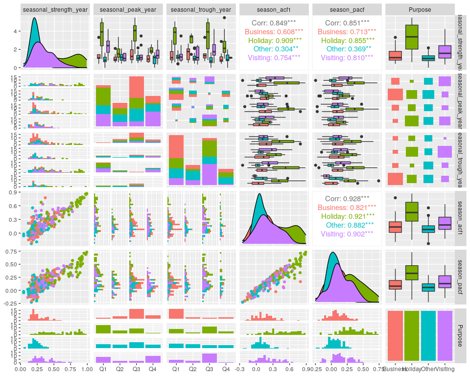

```r
library(glue)
tourism_features %>%
  select_at(vars(contains("season"), Purpose)) %>%
  mutate(
    seasonal_peak_year = seasonal_peak_year +
      4*(seasonal_peak_year==0),
    seasonal_trough_year = seasonal_trough_year +
      4*(seasonal_trough_year==0),
    seasonal_peak_year = glue("Q{seasonal_peak_year}"),
    seasonal_trough_year = glue("Q{seasonal_trough_year}"),
  ) %>%
  GGally::ggpairs(mapping = aes(colour = Purpose))
```

Otra opción interesante es apllcarles una técnica de reducción de dimensionalidad como PCA:

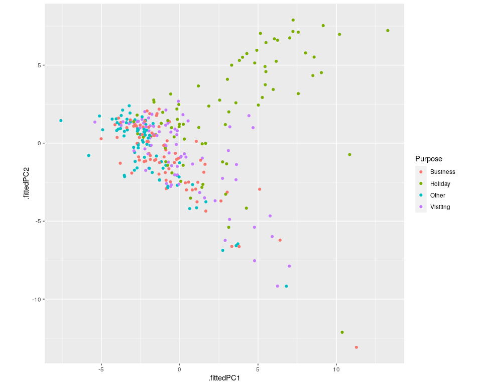

```r
pcs <- tourism_features %>%
  select(-State, -Region, -Purpose) %>%
  prcomp(scale = TRUE) %>%
  augment(tourism_features)
pcs %>%
  ggplot(aes(x = .fittedPC1, y = .fittedPC2, col = Purpose)) +
  geom_point() +
  theme(aspect.ratio = 1)
```

Ahí podemos ver cómo por la componente 2 parece estar separando a los viajes vacacionales del resto. Ytambién cómo hay 4 puntos (los de valores más alto en la componente 1) que parecen estar separados del resto. Si quisiera, podría identificarlos y ver qué tienen de especial:

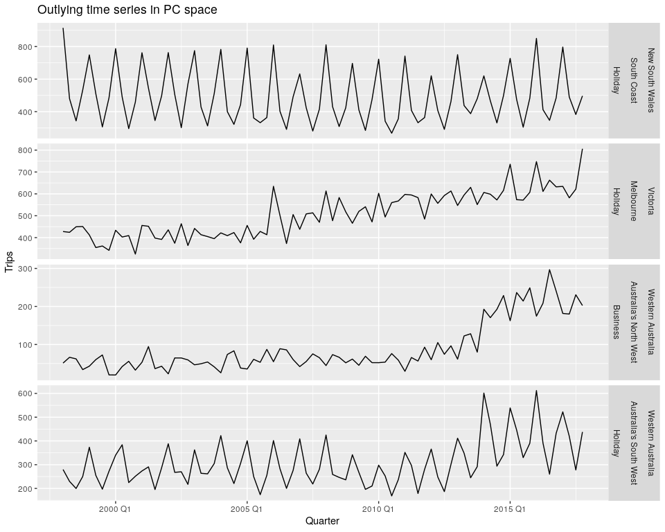

```r
outliers <- pcs %>%
  arrange(desc(.fittedPC1)) %>%
  head(4) %>%
  select(Region, State, Purpose, .fittedPC1, .fittedPC2)

outliers %>%
  left_join(tourism, by = c("State", "Region", "Purpose")) %>%
  mutate(
    Series = glue("{State}", "{Region}", "{Purpose}",
                  .sep = "\n\n")
  ) %>%
  ggplot(aes(x = Quarter, y = Trips)) +
  geom_line() +
  facet_grid(Series ~ ., scales = "free") +
  labs(title = "Outlying time series in PC space")
```